# Quais gastos interferem no lucro de uma startup ?

Mateus de Lima Oliveira

05 de julho de 2019

```r
library(tidyverse)
library(ggbeeswarm)
library(ggplot2)
library(corrplot)
library(broom)

knitr::opts_chunk$set(tidy = FALSE, fig.width = 8, fig.height = 6, echo = TRUE)

options(scipen = 999)

dataset = read_csv(here::here("data/50_startups.csv"),
                 col_types = "dddcd")

names(dataset)[names(dataset) == 'ReD'] <- 'PeD'
names(dataset)[names(dataset) == 'Administration'] <- 'Administracao'
names(dataset)[names(dataset) == 'State'] <- 'Estado'
names(dataset)[names(dataset) == 'Profit'] <- 'Lucro'
```

## Motivação

Os dados utilizados possuem informações sobre 50 startups. Temos cinco colunas que contêm informações sobre quanto essas empresas gastam em administração, pesquisa e desenvolvimento (P&D) e marketing, sua localização por estado e seu lucro no ano mais recente. Este conjunto de dados é anonimizado, o que significa que não sabemos os nomes dessas startups ou qualquer outra informação de identificação.

Pensamos no cenário em que seríamos contratados para analisar essas informações e criar um modelo. Precisaríamos responder ao contratante em quais departamentos da empresa devem-se investir para se obter um maior lucro, por exemplo em administração, ou em outro setor. O nosso empregador informou que deseja tomar essa decisão com base no lucro do ano passado.

Para resolver esse problema, criaremos um modelo para avaliar quais departamentos de uma startup são interessantes para se investir, a fim maximizar seu lucro.

## Análise Descritiva

### Administração

Com base nas visualizações abaixo, podemos notar que há uma dispersão dos pontos, de modo que não se pode afirmar que há uma correlação considerável entre os gastos com administração e o lucro da startup. Nos três estados, existem pontos que estão no mesmo nível de lucro mesmo com o crescimento dos gastos em administração.

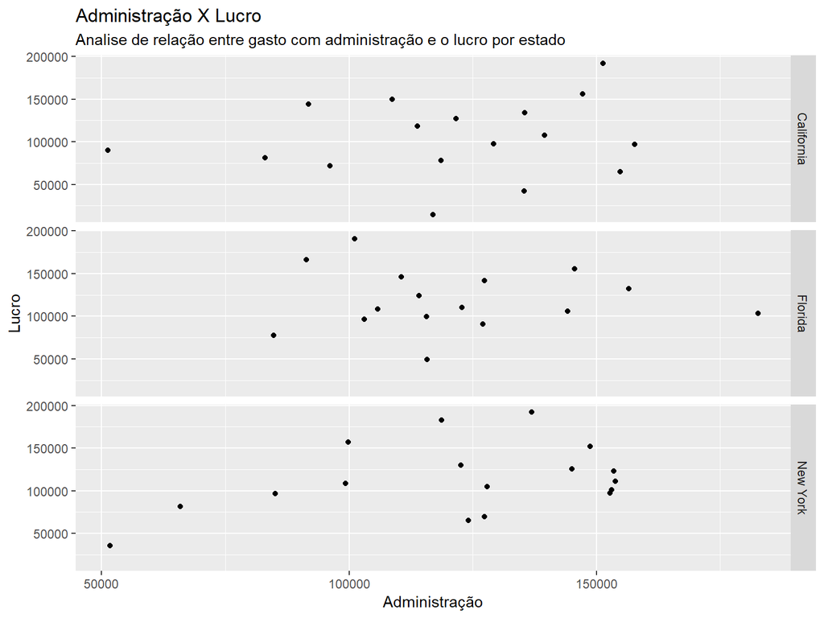

```r
ggplot(data = dataset) +
    theme(legend.position="none")+
    geom_point(aes(x = Administracao, y = Lucro)) +
    facet_grid(Estado ~ .) +
    labs(x = "Administração", y = "Lucro", title = "Administração X Lucro", subtitle =  "Analise de relação entre gasto com administração e o lucro por estado")
```

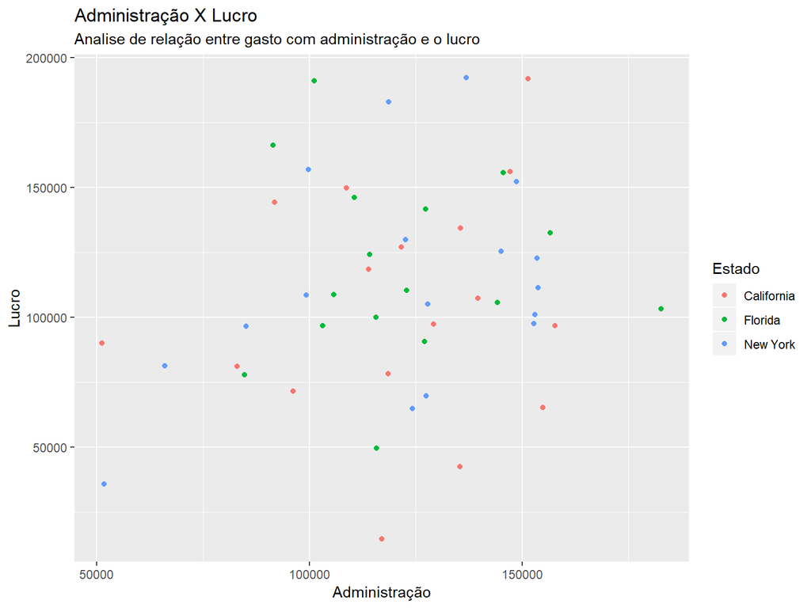

```r
ggplot(data = dataset) +
    geom_point(aes(x = Administracao, y = Lucro, color = Estado))+
    labs(x = "Administração", y = "Lucro", title = "Administração X Lucro", subtitle =  "Analise de relação entre gasto com administração e o lucro")
```

### Marketing

No marketing, a situação difere da administração. As startups tendem a ter um maior lucro de acordo com o investimento nesse setor nos três estados, pois ao passo que o valor investido cresce, os lucros também crescem. Observa-se pontos que fogem da têndencia, logo, há uma correlação considerável entre essas duas variáveis.

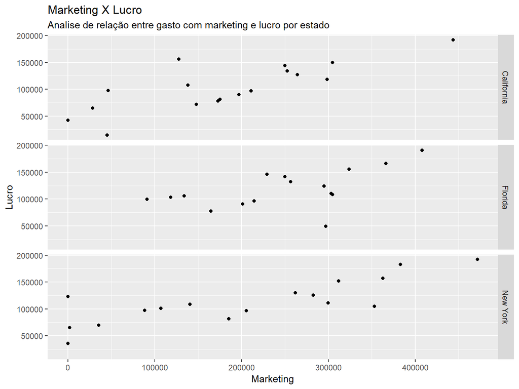

```r
ggplot(data = dataset) +
    theme(legend.position="none")+
    geom_point(aes(x = Marketing, y = Lucro))+
    facet_grid(Estado ~ .) +
    labs(x = "Marketing", y = "Lucro", title = "Marketing X Lucro", subtitle =  "Analise de relação entre gasto com marketing e lucro por estado")
```

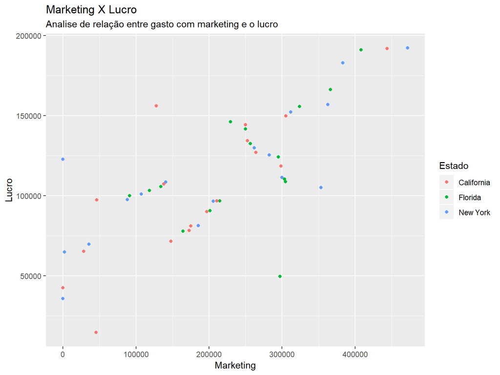

```r
ggplot(data = dataset) +
    geom_point(aes(x = Marketing, y = Lucro, color= Estado))+
    labs(x = "Marketing", y = "Lucro", title = "Marketing X Lucro", subtitle =  "Analise de relação entre gasto com marketing e o lucro")
```

### Pesquisa e Desenvolvimento

Como esperado, há uma correlação quase linear em relação ao lucro e o investimento em pesquisa e desenvolvimento. Não há pontos consideráveis que saiam da têndencia de crescimento linear que os pontos do gráfico seguem. Com isso, esse é o setor que gera um efeito positivo mais provável no lucro das startups quando comparado com Marketing e Administração.

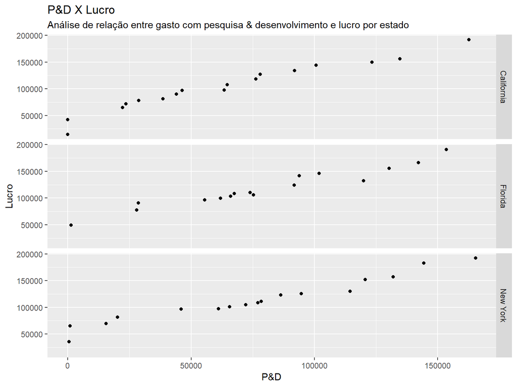

```r
ggplot(data = dataset) +
    theme(legend.position="none")+
    geom_point(aes(x = PeD, y = Lucro)) +
    facet_grid(Estado ~ .) +
    labs(x = "P&D", y = "Lucro", title = "P&D X Lucro", subtitle =  "Análise de relação entre gasto com pesquisa & desenvolvimento e lucro por estado")
```

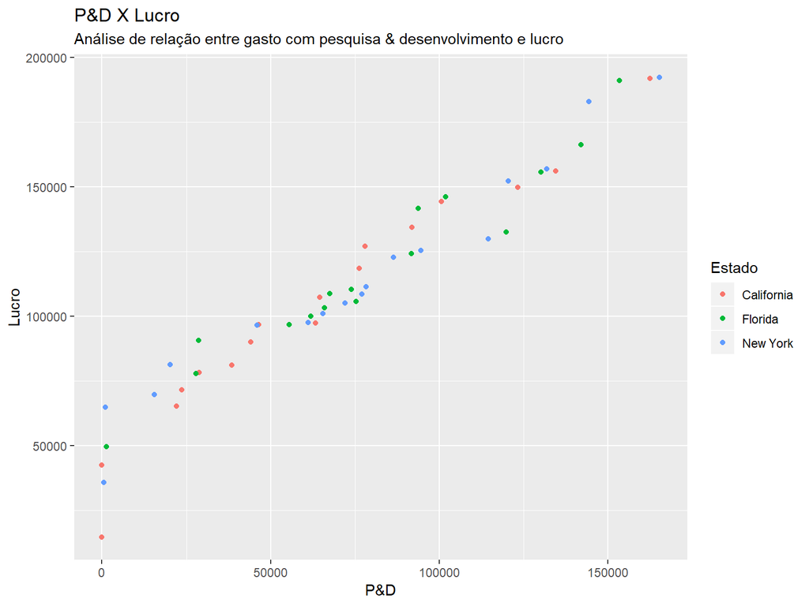

```r
ggplot(data = dataset) +
    geom_point(aes(x = PeD, y = Lucro, color = Estado)) +
    labs(x = "P&D", y = "Lucro", title = "P&D X Lucro", subtitle =  "Análise de relação entre gasto com pesquisa & desenvolvimento e lucro")
```

### Correlações

Para avaliar as correlações entre as variaveis, analisaremos o heatmap abaixo:

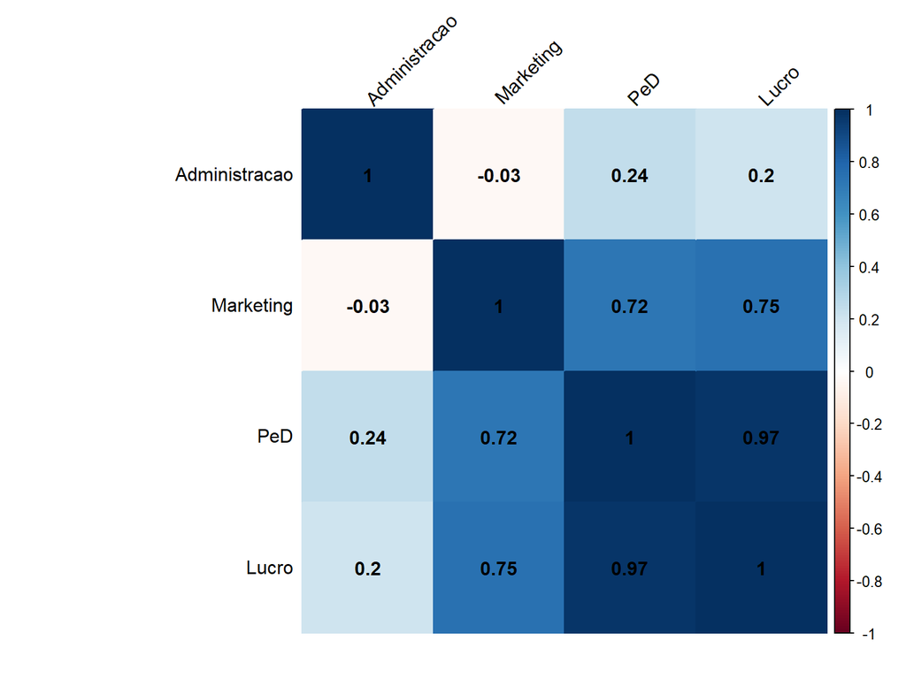

```r
numerical_columns = dataset[c("PeD", "Lucro", "Administracao", "Marketing")]
corrplot(cor(numerical_columns), method="color",
         order="hclust",
         addCoef.col = "black",
         tl.col="black", tl.srt=45,
         sig.level = 0.01, insig = "blank"
         )
```

Como ja tinhamos visto nas visualizações anteriores, Pesquisa e Desenvolvimento e Lucro tem a maior correlação entre as variaveis, de **0.97**.

### Comparação dos lucros por estados

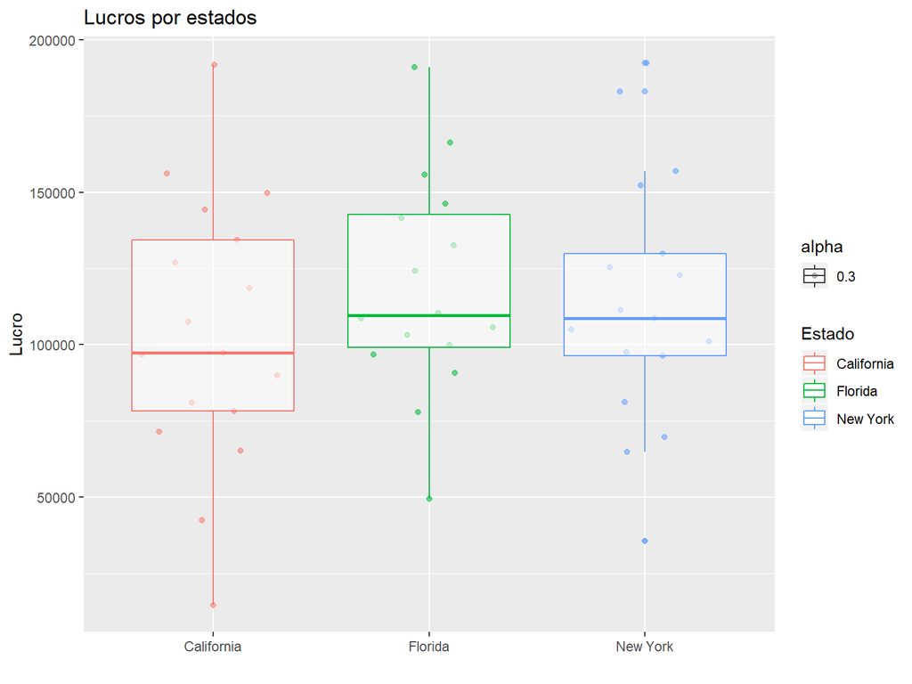

```r
ggplot(data = dataset) +
    geom_quasirandom(aes(x = Estado, y = Lucro, color = Estado, alpha = 0.3))+
    geom_boxplot(aes(x = Estado, y = Lucro, color = Estado, alpha = 0.3))+
    labs(x = "", y = "Lucro", title = "Lucros por estados")
```

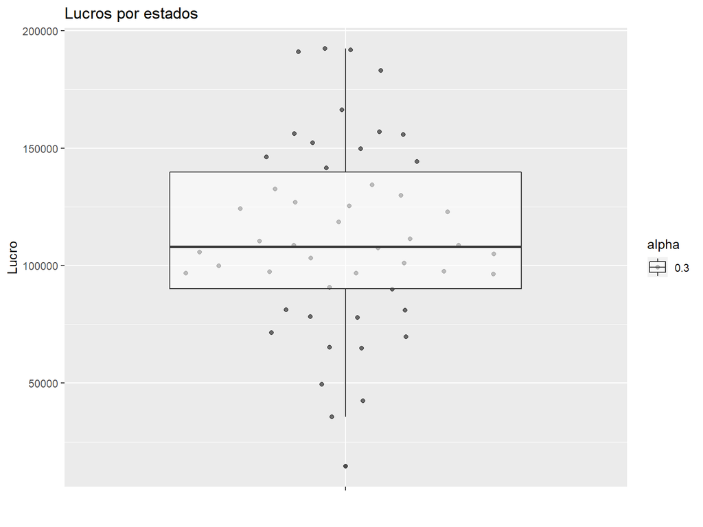

```r
ggplot(data = dataset) +
    geom_quasirandom(aes(x = "" , y = Lucro, alpha = 0.3))+
    geom_boxplot(aes(x = "", y = Lucro, alpha = 0.3))+
    labs(x = "", y = "Lucro", title = "Lucros por estados")
```

## Modelo

Iremos montar o modelo considerando todas as variaveis que porem impactar no lucro.

```r
lm_lucro <- lm(Lucro ~ PeD + Marketing + Administracao + Estado, data = dataset)
tidy(lm_lucro)
```

| term | estimate | std.error | statistic | p.value |
| --- | --- | --- | --- | --- |
| (Intercept) | 50125.34383167 | 6884.81972986 | 7.28056010 | 0.000000004444178386336665960 |
| PeD | 0.80602311 | 0.04640697 | 17.36858046 | 0.000000000000000000002578772 |
| Marketing | 0.02697986 | 0.01714216 | 1.57388945 | 0.122676927078637615364797853 |
| Administracao | -0.02700432 | 0.05223155 | -0.51701165 | 0.607737326811448985708352666 |
| EstadoFlorida | 198.78879286 | 3371.00712393 | 0.05897015 | 0.953242901222403959948792362 |
| EstadoNew York | -41.88701913 | 3256.03912800 | -0.01286441 | 0.989794124160751520591361441 |

```r
glance(lm_lucro)
```

| r.squared | adj.r.squared | sigma | statistic | p.value | df | logLik | AIC | BIC | deviance | df.residual |
| --- | --- | --- | --- | --- | --- | --- | --- | --- | --- | --- |
| 0.9507525 | 0.9451562 | 9439.207 | 169.8892 | 0.000000000000000000000000001339547 | 6 | -525.3825 | 1064.765 | 1078.149 | 3920339644 | 44 |

## Ou seja..

Considere **MKT** sendo Marketing e **ADM** sendo Administração.